# Review of Geospatial Data Visualization

Last Updated 2023-03-14

The midterm exam is scheduled for our next class session. This portion of today’s class is designed to review some of the more important aspects of geospatial data visualization that we have covered to date.

To this end, you have a shapefile of (redacted) flood insurance claims paid in the state of Virginia compiled by the Federal Emergency Management Administration included in the .zip file. You can read more about the [source of these data here](https://www.fema.gov/openfema-data-page/fima-nfip-redacted-claims-v1) if you like.

Below, we read in the shapefile from hard disk using the *sf::st_read* function…

```r
va_nfip_claims_0 <- st_read("NFIP_Claims_VA.shp")
```

Now let’s practice some of the technical operations that are likely to appear on the midterm exam.

Hurricane Isabel hit Virginia in September of 2003 and it remains the [costliest disaster in the state’s history](https://en.wikipedia.org/wiki/Effects_of_Hurricane_Isabel_in_Virginia#:~:text=The%20effects%20of%20Hurricane%20Isabel,in%20the%20tropical%20Atlantic%20Ocean.). Let’s explore flood insurance claims from 2003 just to get a little more practice under our belts.

```r
# Check the coordinate system of the data layer we just imported...
st_crs(va_nfip_claims_0)
```

```
## Coordinate Reference System:
##   User input: WGS 84
##   wkt:
## GEOGCRS["WGS 84",
##     DATUM["World Geodetic System 1984",
##         ELLIPSOID["WGS 84",6378137,298.257223563,
##             LENGTHUNIT["metre",1]]],
##     PRIMEM["Greenwich",0,
##         ANGLEUNIT["degree",0.0174532925199433]],
##     CS[ellipsoidal,2],
##         AXIS["latitude",north,
##             ORDER[1],
##             ANGLEUNIT["degree",0.0174532925199433]],
##         AXIS["longitude",east,
##             ORDER[2],
##             ANGLEUNIT["degree",0.0174532925199433]],
##     ID["EPSG",4326]]
```

```r
# Apply a map projection... maybe UTM Zone 17 North...
va_nfip_claims <- st_transform(va_nfip_claims_0, crs = "EPSG:32617")

# Check the coordinate system again...
st_crs(va_nfip_claims)
```

```
## Coordinate Reference System:
##   User input: EPSG:32617
##   wkt:
## PROJCRS["WGS 84 / UTM zone 17N",
##     BASEGEOGCRS["WGS 84",
##         DATUM["World Geodetic System 1984",
##             ELLIPSOID["WGS 84",6378137,298.257223563,
##                 LENGTHUNIT["metre",1]]],
##         PRIMEM["Greenwich",0,
##             ANGLEUNIT["degree",0.0174532925199433]],
##         ID["EPSG",4326]],
##     CONVERSION["UTM zone 17N",
##         METHOD["Transverse Mercator",
##             ID["EPSG",9807]],
##         PARAMETER["Latitude of natural origin",0,
##             ANGLEUNIT["degree",0.0174532925199433],
##             ID["EPSG",8801]],
##         PARAMETER["Longitude of natural origin",-81,
##             ANGLEUNIT["degree",0.0174532925199433],
##             ID["EPSG",8802]],
##         PARAMETER["Scale factor at natural origin",0.9996,
##             SCALEUNIT["unity",1],
##             ID["EPSG",8805]],
##         PARAMETER["False easting",500000,
##             LENGTHUNIT["metre",1],
##             ID["EPSG",8806]],
##         PARAMETER["False northing",0,
##             LENGTHUNIT["metre",1],
##             ID["EPSG",8807]]],
##     CS[Cartesian,2],
##         AXIS["(E)",east,
##             ORDER[1],
##             LENGTHUNIT["metre",1]],
##         AXIS["(N)",north,
##             ORDER[2],
##             LENGTHUNIT["metre",1]],
##     USAGE[
##         SCOPE["Engineering survey, topographic mapping."],
##         AREA["Between 84°W and 78°W, northern hemisphere between equator and 84°N, onshore and offshore. Bahamas. Ecuador - north of equator. Canada - Nunavut; Ontario; Quebec. Cayman Islands. Colombia. Costa Rica. Cuba. Jamaica. Nicaragua. Panama. United States (USA)."],
##         BBOX[0,-84,84,-78]],
##     ID["EPSG",32617]]
```

```r
# Filter out records where year of loss is 2003
va_nfip_claims_2003 <- va_nfip_claims %>%
  filter(yrOfLss == 2003)


# Get a layer with boundaries for context...
bound_0 <- st_read("https://opendata.arcgis.com/datasets/e3c8822a4adc4fc1a542a233893a46d4_0.geojson")
```

```r
# Apply a map projection... maybe UTM Zone 17 North... to be consistent!
bound <- st_transform(bound_0, crs = "EPSG:32617")


# View the breakdown of payments by structure type...
tabyl(va_nfip_claims_2003$occpncT)
```

| va_nfip_claims_2003$occpncT | n | percent |
| --- | --- | --- |
| 1 | 928 | 0.967674661 |
| 2 | 22 | 0.022940563 |
| 3 | 8 | 0.008342023 |
| 4 | 1 | 0.001042753 |

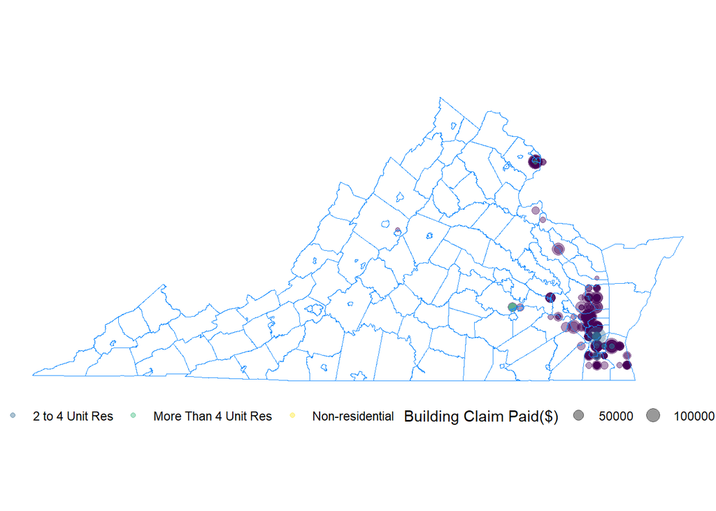

```r
# Map claims by structure type AND payment amount, KNOWING that the vast
# majority of structure were single-family residential...
ggplot() +
  geom_sf(data = va_nfip_claims_2003, aes(color = as_factor(occpncT), size = amnPOBC), shape = 19, alpha = 0.4) +
  geom_sf(data = bound, color = "dodgerblue", fill = NA) +
  scale_color_viridis(discrete = TRUE, name = "Structure Type", labels = c("Single Family Res",
                                                                           "2 to 4 Unit Res",
                                                                           "More Than 4 Unit Res",
                                                                           "Non-residential")) +
  scale_size_continuous(name = "Building Claim Paid($)") +
  coord_sf(crs = st_crs(4326)) +
  theme_void() +
  theme(legend.position="bottom")
```

We can also bring exploratory data analysis to bear here…

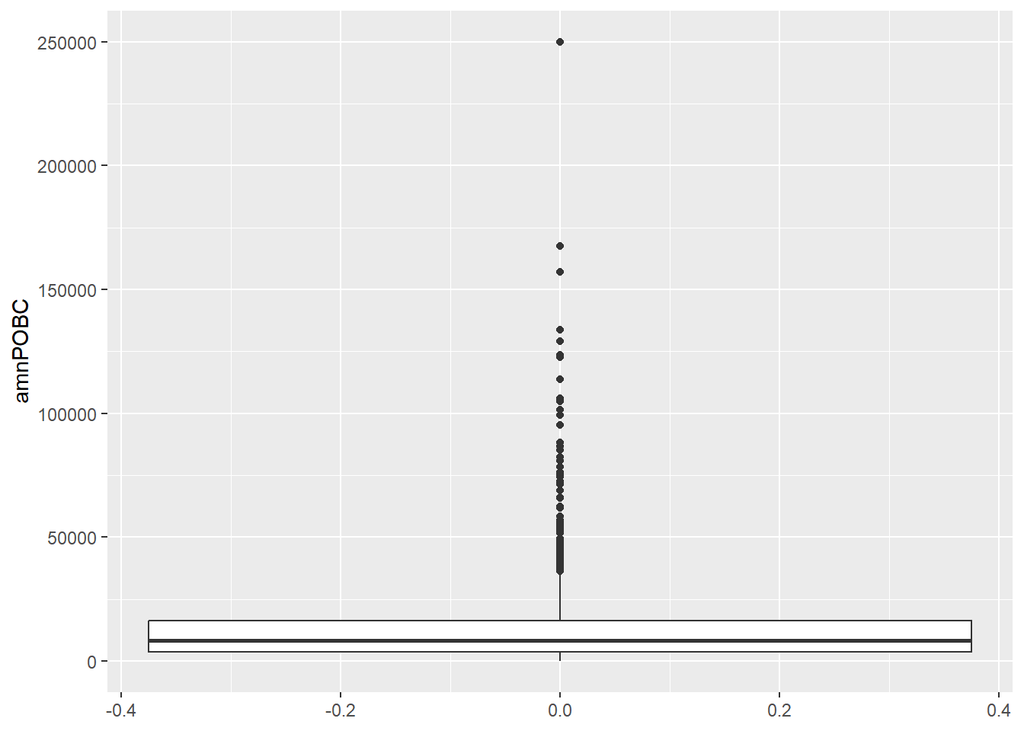

```r
# Create boxplot of building claims paid...
ggplot() +
  geom_boxplot(data = va_nfip_claims_2003, aes(y = amnPOBC))
```

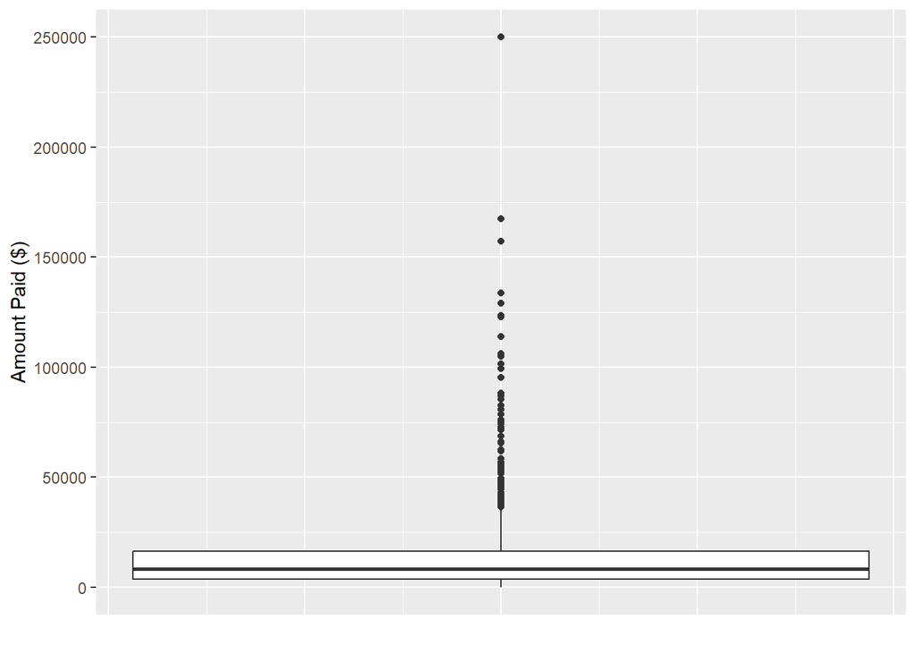

```r
# Modify the axis labels...
ggplot() +
  geom_boxplot(data = va_nfip_claims_2003, aes(y = amnPOBC)) +
  labs(x = "", y = "Amount Paid ($)") +
  theme(axis.text.x = element_blank(),
        axis.ticks.x = element_blank())
```

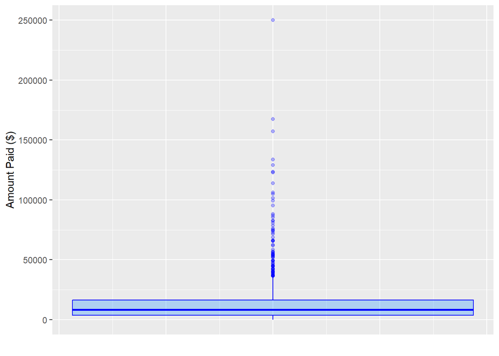

```r
# Change the color...
ggplot() +
  geom_boxplot(data = va_nfip_claims_2003, aes(y = amnPOBC), color = "blue", fill = "dodgerblue", alpha = 0.3) +
  labs(x = "", y = "Amount Paid ($)") +
  theme(axis.text.x = element_blank(),
        axis.ticks.x = element_blank())
```

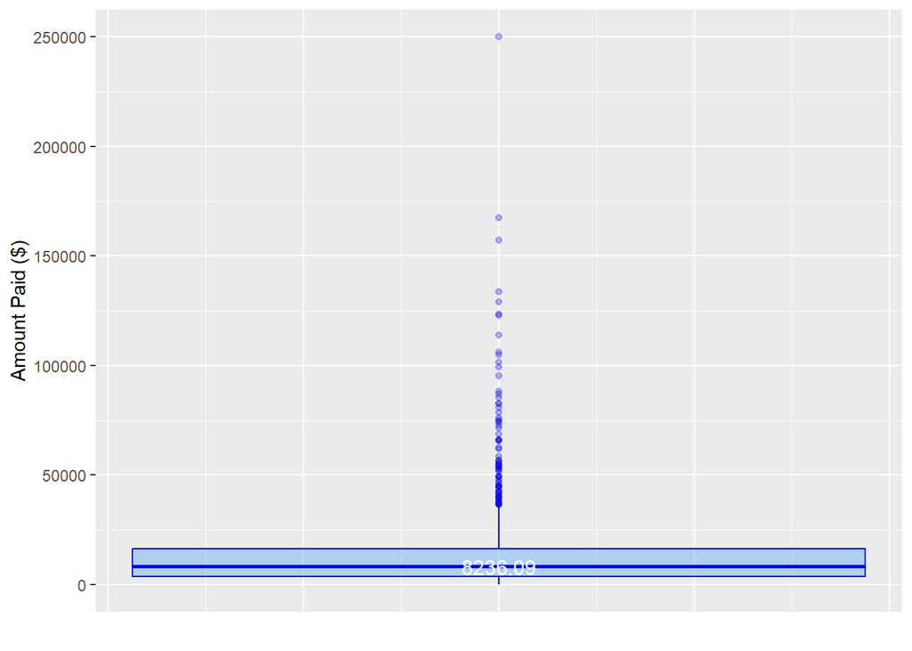

```r
# Label the median...
ggplot() +
  geom_boxplot(data = va_nfip_claims_2003, aes(y = amnPOBC), color = "blue", fill = "dodgerblue", alpha = 0.3) +
  labs(x = "", y = "Amount Paid ($)") +
  theme(axis.text.x = element_blank(),
        axis.ticks.x = element_blank()) +
  annotate("text", label = median(va_nfip_claims_2003$amnPOBC, na.rm = TRUE), x = 0, y = median(va_nfip_claims_2003$amnPOBC, na.rm = TRUE), size = 4, color = "white")
```

Continue with the EDA motif…

```r
# Summarise by structure type...
sfr_claims <- st_drop_geometry(va_nfip_claims_2003) %>%
  group_by(occpncT) %>%
  summarise(MeanPayment = mean(amnPOBC, na.rm = TRUE))

str(sfr_claims)
```

```
## tibble [4 × 2] (S3: tbl_df/tbl/data.frame)
##  $ occpncT    : int [1:4] 1 2 3 4
##  $ MeanPayment: num [1:4] 15236 22744 13958 NaN
```

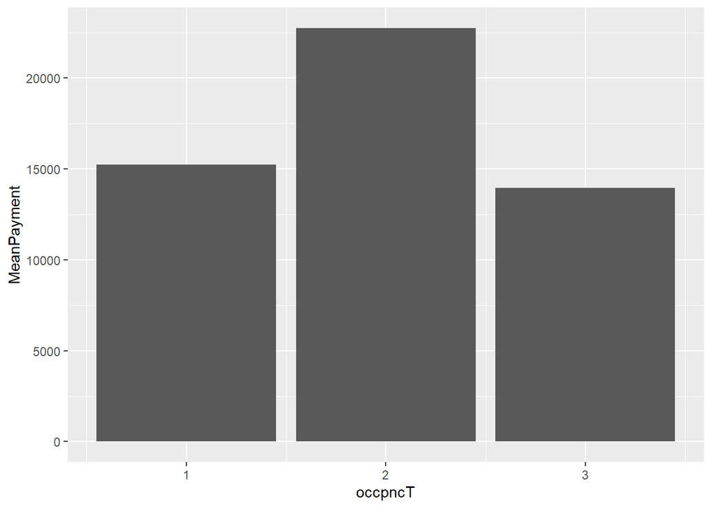

```r
# Create a barchart...
sfr_claims %>%
  drop_na(MeanPayment) %>%
ggplot() +
  geom_bar(aes(x = occpncT , y = MeanPayment), stat = "identity")
```

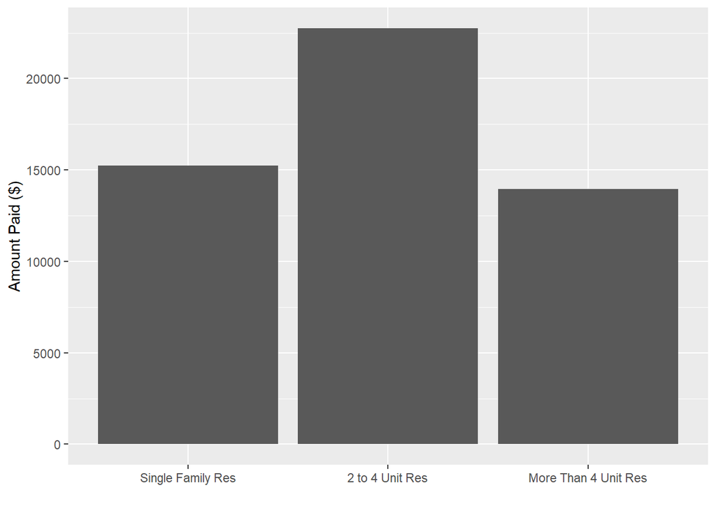

```r
# Change the axis labels...
sfr_claims %>%
  drop_na(MeanPayment) %>%
ggplot() +
  geom_bar(aes(x = as_factor(occpncT), y = MeanPayment), stat = "identity") +
  labs(x = "", y = "Amount Paid ($)") +
  scale_x_discrete(labels = c("Single Family Res", "2 to 4 Unit Res", "More Than 4 Unit Res"))
```

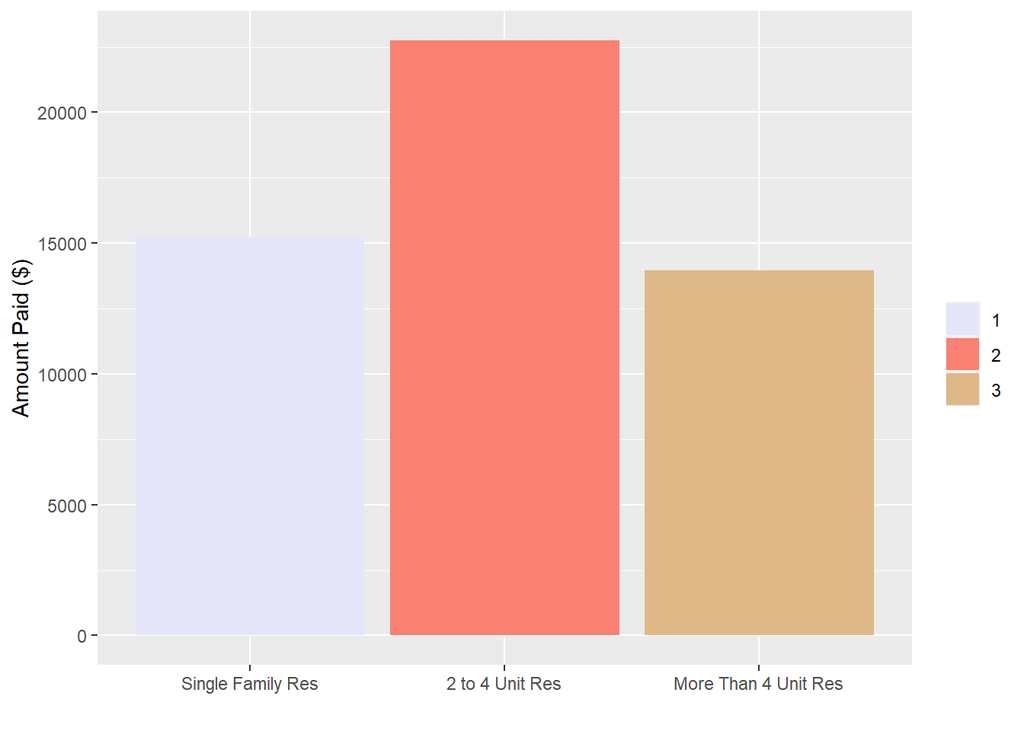

```r
# Change the fill colors...
sfr_claims %>%
  drop_na(MeanPayment) %>%
ggplot() +
  geom_bar(aes(x = as_factor(occpncT), y = MeanPayment, fill = as_factor(occpncT)), stat = "identity") +
  labs(x = "", y = "Amount Paid ($)") +
  scale_x_discrete(labels = c("Single Family Res", "2 to 4 Unit Res", "More Than 4 Unit Res")) +
  scale_fill_manual(name = "", values = c("lavender", "salmon", "burlywood") )
```

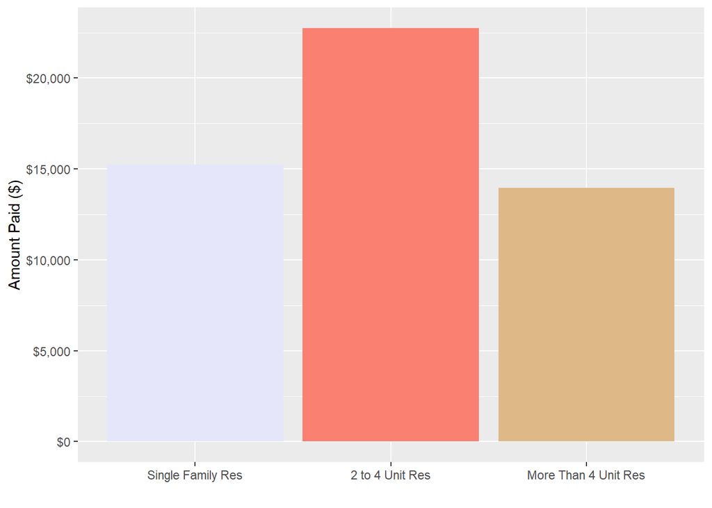

```r
# Suppress the legend and format the y-axis values...
sfr_claims %>%
  drop_na(MeanPayment) %>%
ggplot() +
  geom_bar(aes(x = as_factor(occpncT), y = MeanPayment, fill = as_factor(occpncT)),
           stat = "identity", show.legend = FALSE) +
  labs(x = "", y = "Amount Paid ($)") +
  scale_x_discrete(labels = c("Single Family Res", "2 to 4 Unit Res", "More Than 4 Unit Res")) +
  scale_fill_manual(name = "", values = c("lavender", "salmon", "burlywood")) +
  scale_y_continuous(labels = scales::dollar_format())
```

You guessed it… more EDA…

```r
# Calculate mean payment amount by structure type
sfr_claims <- st_drop_geometry(va_nfip_claims_2003) %>%
  group_by(occpncT) %>%
  summarise(MeanPayment = mean(amnPOBC, na.rm = TRUE))

str(sfr_claims)
```

```
## tibble [4 × 2] (S3: tbl_df/tbl/data.frame)
##  $ occpncT    : int [1:4] 1 2 3 4
##  $ MeanPayment: num [1:4] 15236 22744 13958 NaN
```

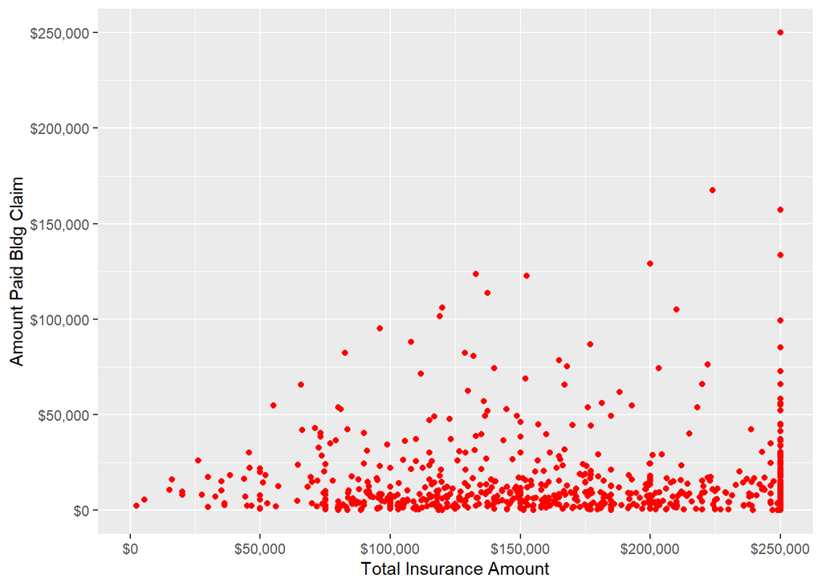

```r
# Plot total insurance coverage amount by amount paid for a given claim...
ggplot() +
  geom_point(data = va_nfip_claims_2003, aes(y = amnPOBC, x = ttlBlIC), color = "red") +
  labs(x = "Total Insurance Amount", y = "Amount Paid Bldg Claim") +
  scale_x_continuous(labels = scales::dollar_format()) +
  scale_y_continuous(labels = scales::dollar_format())
```

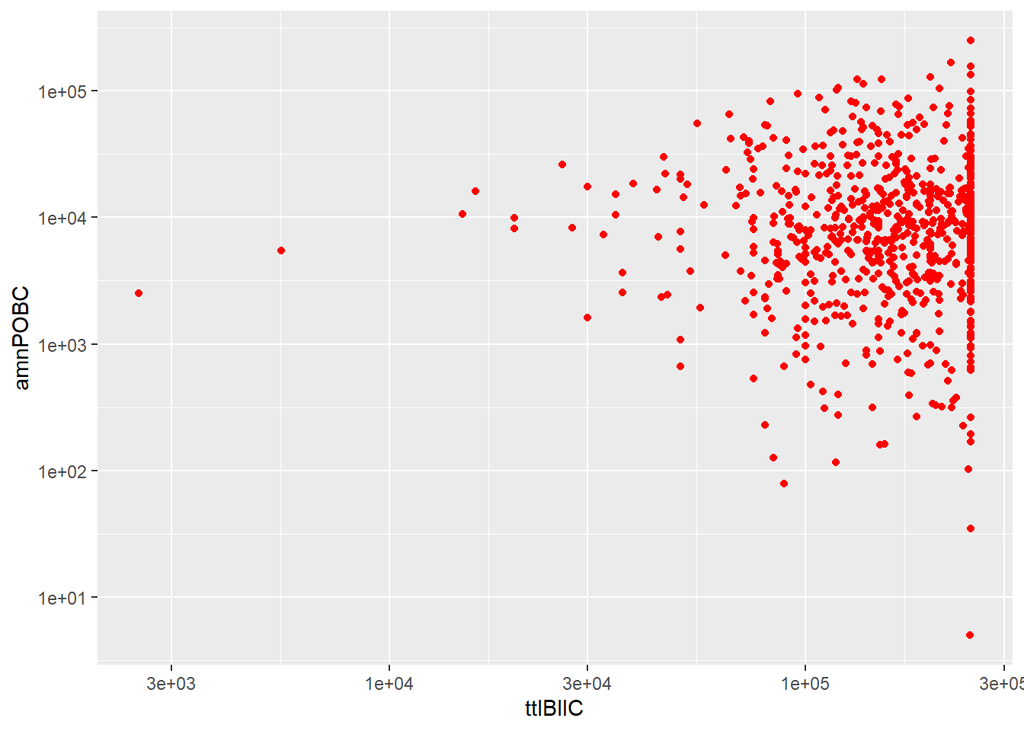

```r
# What if we log-transform the data to make the pattern easier to see?
ggplot() +
  geom_point(data = va_nfip_claims_2003, aes(y = amnPOBC, x = ttlBlIC), color = "red") +
  scale_x_log10() + scale_y_log10()
```

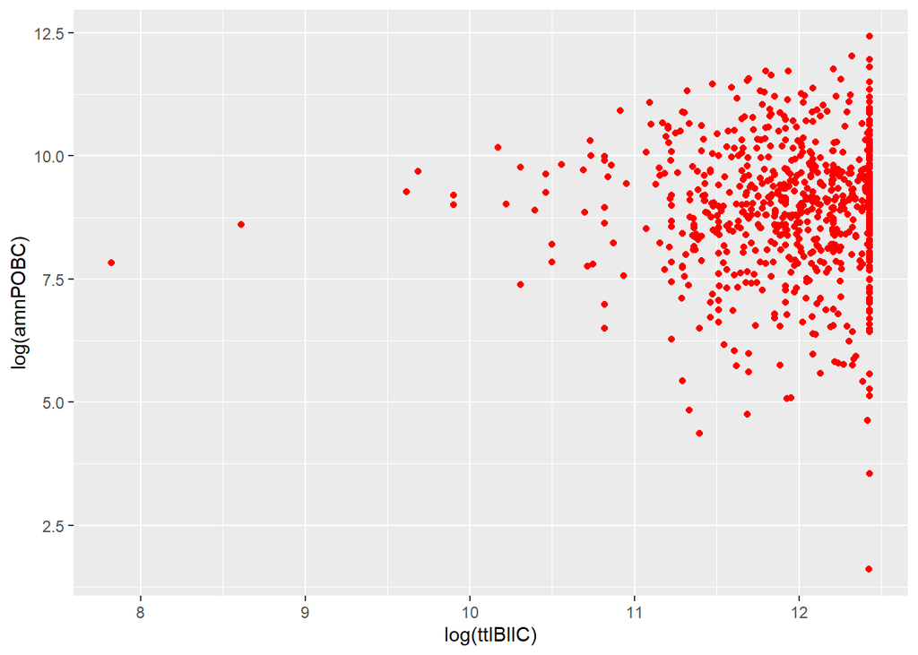

```r
# What if we log-transform the data the hard way?
va_nfip_claims_2003 %>%
  filter(amnPOBC > 0.0) %>%
  ggplot() +
  geom_point(aes(y = log(amnPOBC), x = log(ttlBlIC)), color = "red")
```

```r
# The maximum insurance policy amount at this time was $250,000...
summary(va_nfip_claims_2003$ttlBlIC)
```

```
##    Min. 1st Qu.  Median    Mean 3rd Qu.    Max.
##       0  116000  166900  166104  237800  250000
```

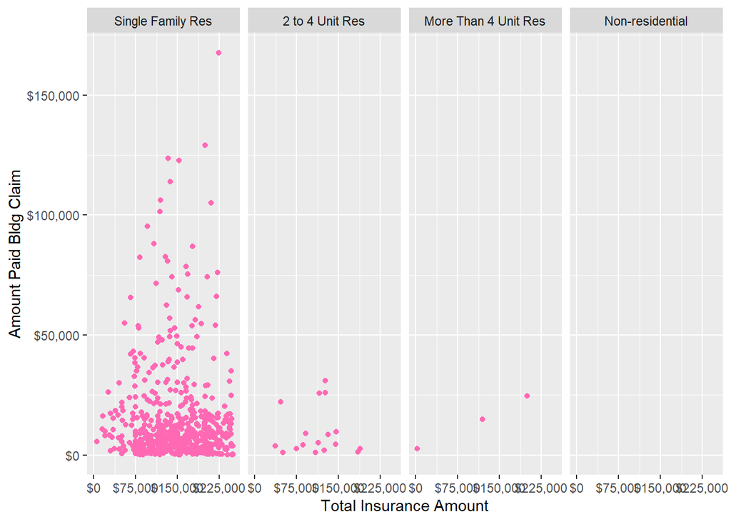

```r
# Let's demonstrate who we might facet these scatterplots...
facet_labels_for_plot <- c("1" = "Single Family Res",
                           "2" = "2 to 4 Unit Res",
                           "3" = "More Than 4 Unit Res",
                           "4" = "Non-residential")

va_nfip_claims_2003 %>%
  filter(ttlBlIC < 250000) %>%
  ggplot() +
  geom_point(aes(y = amnPOBC, x = ttlBlIC), color = "hotpink") +
  labs(x = "Total Insurance Amount", y = "Amount Paid Bldg Claim") +
  scale_x_continuous(labels = scales::dollar_format(), breaks = c(seq(0, 250000, 75000))) +
  scale_y_continuous(labels = scales::dollar_format()) +
  facet_grid(. ~ occpncT, labeller = labeller(occpncT = facet_labels_for_plot))
```

```r
# Note that we have to use the labeller function here, which could be a hassle AND that
# we increase the spacing between x-axis labels for legibility using the breaks argument...
```

Now let’s make a map or two… 🗺 💪

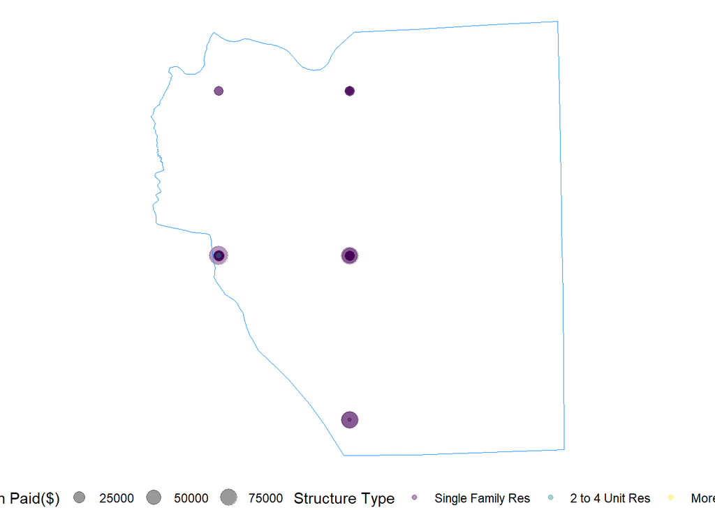

```r
# Note that FEMA "fuzzies" the latitude and longitude of these claims a bit...


# Here we plot flood insurance claims from Mathews County during 2003 by
# chaining the ggplot code to a dplyr::filter operation...
va_nfip_claims_2003 %>%
  filter(contyCd == 51115) %>%
ggplot() +
  geom_sf(aes(color = as_factor(occpncT), size = amnPOBC), shape = 19, alpha = 0.4) +
  geom_sf(data = bound[bound$GEOID == "51115", ], color = "dodgerblue", fill = NA) +
  scale_color_viridis(discrete = TRUE, name = "Structure Type", labels = c("Single Family Res",
                                                                           "2 to 4 Unit Res",
                                                                           "More Than 4 Unit Res",
                                                                           "Non-residential")) +
  scale_size_continuous(name = "Building Claim Paid($)") +
  coord_sf(crs = st_crs(4326)) +
  theme_void() +
  theme(legend.position="bottom")
```

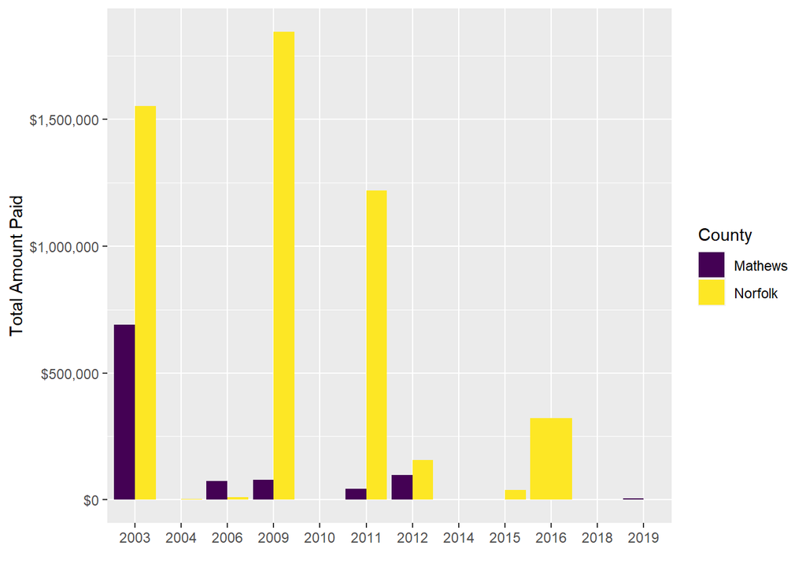

```r
# We can use a similar approach to create a barchart showing claims paid in Mathews County versus
# Norfolk County since 2003... apologies for the color selections...
va_nfip_claims %>%
  filter(contyCd %in% c(51115, 51710),
         yrOfLss > 2002) %>%
  group_by(contyCd, yrOfLss) %>%
  summarise(TotalPaid = sum(amnPOBC, na.rm = TRUE), TotalClaims = n()) %>%
ggplot(aes(x = as_factor(yrOfLss), y = TotalPaid, fill = contyCd)) +
    geom_bar(position="dodge", stat="identity") +
    scale_fill_viridis(discrete = TRUE, name = "County",
                       labels = c("Mathews", "Norfolk")) +
    scale_y_continuous(labels = scales::dollar_format()) +
    labs(x = "", y = "Total Amount Paid")
```

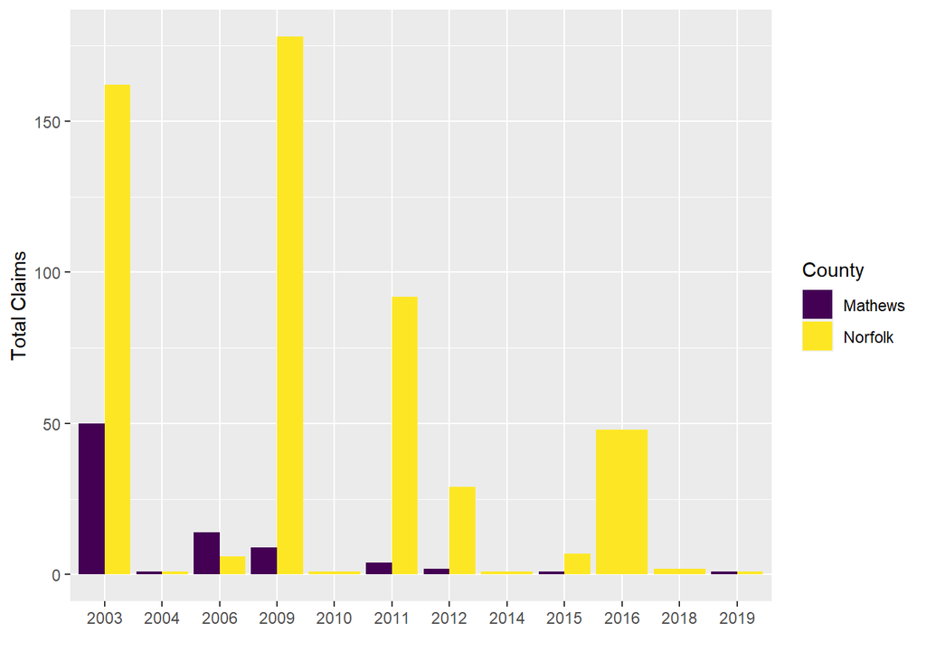

```r
# We can do the same with total flood insurance claims submitted from these two counties...
va_nfip_claims %>%
  filter(contyCd %in% c(51115, 51710),
         yrOfLss > 2002) %>%
  group_by(contyCd, yrOfLss) %>%
  summarise(TotalPaid = sum(amnPOBC, na.rm = TRUE), TotalClaims = n()) %>%
ggplot(aes(x = as_factor(yrOfLss), y = TotalClaims, fill = contyCd)) +
    geom_bar(position="dodge", stat="identity") +
    scale_fill_viridis(discrete = TRUE, name = "County",
                       labels = c("Mathews", "Norfolk")) +
    labs(x = "", y = "Total Claims")
```

Maybe flooding issues are waning in these two counties if we use this data as a point of departure? 😉

As shown [here](https://www.mathewscountyva.gov/171/Flood-Zones), zones A, AE, and VE are considered part of the 100-year floodplain in Mathews County (and elsewhere, but you get my point). The other shapefile shows FEMA flood risk for Mathews County and we can overlay it with the (“fuzzied” for privacy) location of flood insurance claims from there.

```r
# Read in the FEMA shapefile and project it to match our other layers...
fema_0 <- st_read("FEMA_Flood_Map.shp")
```

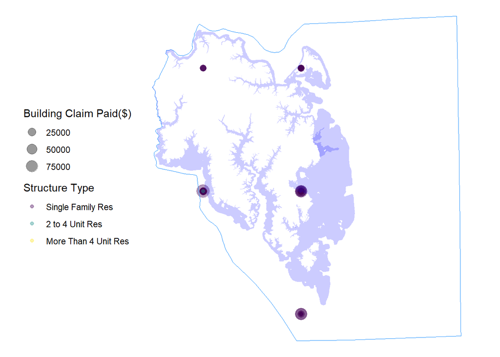

```r
fema <- st_transform(fema_0, crs = "EPSG:32617")

# Use dplyr to only keep zones that are considered in the 100 year floodplain...
fema_100_yr <- fema %>%
  filter(FLD_ZONE %in% c("A", "AE", "VE"))


# Generate the map....
va_nfip_claims %>%
  filter(contyCd == 51115) %>%
ggplot() +
  geom_sf(aes(color = as_factor(occpncT), size = amnPOBC), shape = 19, alpha = 0.4) +
  geom_sf(data = bound[bound$GEOID == "51115", ], color = "dodgerblue", fill = NA) +
  geom_sf(data = fema_100_yr, fill = "blue", color = NA, alpha = 0.2) +
  scale_color_viridis(discrete = TRUE, name = "Structure Type", labels = c("Single Family Res",
                                                                           "2 to 4 Unit Res",
                                                                           "More Than 4 Unit Res",
                                                                           "Non-residential")) +
  scale_size_continuous(name = "Building Claim Paid($)") +
  coord_sf(crs = st_crs(4326)) +
  theme_void() +
  theme(legend.position="left")
```

Recall that we use the `st_crs` function to display the coordinate system for a given *sf* object. We use the `st_transform` function to **change the coordinate system** of a given *sf* object.

You have reached the end!